# Intro Statistics Exersice

# Dices

**What can you say about the difference in the mean and the standard deviation between two six-sided dices and one 12-sided dice?**

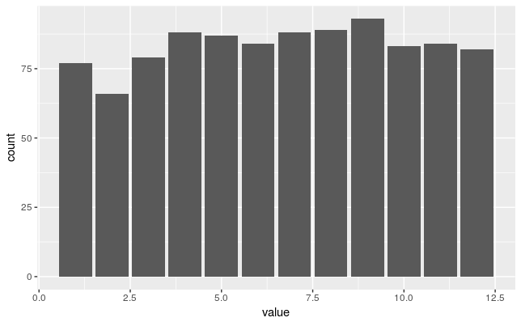

```r
dice_12 <- sample(1:12, 1000, replace = TRUE) %>%
  as_data_frame()
dice_66 <- sample(1:6, 1000, replace = TRUE) + sample(1:6, 1000, replace = TRUE) %>%
  as_data_frame()
ggplot(dice_12) +
  geom_bar(aes(value), stat = "count")
```

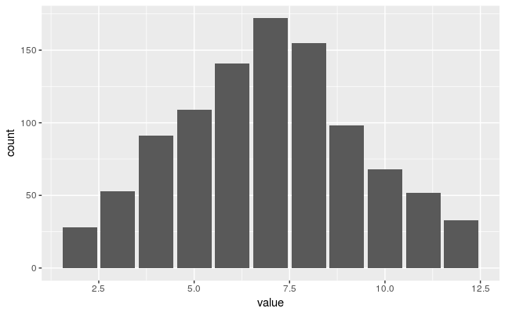

```r
ggplot(dice_66) +
  geom_bar(aes(value), stat = "count")
```

```r
mean(dice_12$value)
```

```
[1] 6.64
```

```r
mean(dice_66$value)
```

```
[1] 6.944
```

```r
sd(dice_12$value)
```

```
[1] 3.375469
```

```r
sd(dice_66$value)
```

```
[1] 2.400547
```

# Medical Consultant

People providing an organ for donation sometimes seek the help of a special medical con- sultant. These consultants assist the patient in all aspects of the surgery, with the goal of reducing the possibility of complications during the medical procedure and recovery. Patients might choose a consultant based in part on the historical complication rate of the consultant’s clients.

## Simulation

**What is the point estimate of the data?**

```r
point_estimate <- 3 / 63
```

**Is it possible to assess the consultant’s claim using the data?**

No. The claim is that there is a causal connection, but the data are observational. For example, maybe patients who can afford a medical consultant can afford better medical care, which can also lead to a lower complication rate.

**Could the low complication rate of 0.048 be due to chance? Formulate the hypotheses for this question.**

**H<sub>0</sub>**: There is no association between the consultant’s contributions and the clients’ complication rate. That is, the complication rate for the consultant’s clients is equal to the US average of 10%. In statistical language, p = 0.10.

**H<sub>A</sub>**: Patients who work with the consultant have a complication rate different than 10%, i.e. p != 0.10.

**Run 1000 simulations to get the distribution of the null hypotheses.**

```r
simulated_point_estimates <-
  data_frame(value = seq(1:1000)) %>%
  mutate(value = 1:1000 %>%
    map_dbl(function(i) {
      sum(
        runif(63) < 0.1
      ) / 63
    }))
mean(simulated_point_estimates$value)
```

```
[1] 0.09988889
```

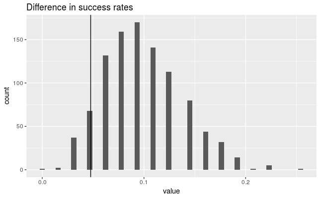

```r
ggplot(simulated_point_estimates) +
  geom_histogram(aes(value), bins = 50) +
  geom_vline(xintercept = point_estimate) +
  labs(title = "Difference in success rates")
```

```r
p_value_sim <- (sum(simulated_point_estimates$value <= point_estimate) * 2) / 1000
```

**Would you reject or accept the H<sub>0</sub> based on this simulation?**

0.216 > 0.05 so we cannot reject the **H<sub>0</sub>**

## Normal model application

**Use the normal distribution to calculate the p-value and see if you draw the same conclusion.**

```r
# Calculate the standard deviation
SE <- sqrt((0.1 * (1 - 0.1) / 63))
# Calculate the Z-score
Z <- (0.1 - point_estimate) / SE
# Calculate the p-value
p_value_norm <- (1- pnorm(Z, 0, 1)) * 2
```

0.1657867 > 0.05 so we cannot reject the **H<sub>0</sub>**

**What can you say about the p-values found using the different methods? Can you explains that?**

They are very different because the distribution is skewed and therefore the normal distribution method cannot be used here.